# Spatial Autocorrelation Analysis

Investigate spatial autocorrelation of higher education population is U.S. Counties following the material covered in class. Use the values for the number of persons over 25 in a county who have a graduate degree or higher. First, set any values that are not significantly different from 0 to zero (z - test using moe). Then -------->

1. Determine weights (use Queen).
2. Binary case: Number of persons over 25 with a graduate or professional degree exceeds the median county value.
   1. Join Counts
3. Global Moran's I
4. Hot and Cold spots (use 90% AND 95% confidence levels)
5. Interpret the results.

## Part 1: Read geographic data using Census FTP

This is an example of using the Census Bureau's FTP to extract county boundaries (spatial data) in contiguous U.S. (48 states). A parallel approach is to use the REST services. I have provided examples of both. If you are not familiar with Census Data and REST services, it may be easier to use the FTP site.

In addition, you will use the Census API to extract attribute data for analysis.

Reading Census geodata from the TigerWeb rest services involves examining the REST Map Services available, including the attributes and query tools. The URL below retrieves the GEOID, STATE, COUNTY, BASENAME, and polygon geometry of all states with a FIPS code < 57 in **geojson format**. The FIPS code for Alabama is 1 and for Wyoming is 56. This code may be used to eliminate terratories like Puerto Rico for the data set. Then Alaska (2) and Hawaii (15) from the dataset.

TIGER REST service https://tigerweb.geo.census.gov/arcgis/rest/services/TIGERweb/tigerWMS_ACS2019/MapServer/86/query?where=STATE%3C57&text=&objectIds=&time=&geometry=&geometryType=esriGeometryEnvelope&inSR=&spatialRel=esriSpatialRelIntersects&relationParam=&outFields=GEOID%2C+STATE%2CCOUNTY%2CBASENAME&returnGeometry=true&returnTrueCurves=false&maxAllowableOffset=&geometryPrecision=&outSR=&returnIdsOnly=false&returnCountOnly=false&orderByFields=&groupByFieldsForStatistics=&outStatistics=&returnZ=false&returnM=false&gdbVersion=&returnDistinctValues=false&resultOffset=&resultRecordCount=&queryByDistance=&returnExtentsOnly=false&datumTransformation=&parameterValues=&rangeValues=&f=geojson

```python
import geopandas as gpd
import pandas as pd
import numpy as np

import os
import requests
import zipfile
import io

import matplotlib.pyplot as plt
%matplotlib inline
```

## TIGER REST Service example

> This takes a while to execute!

```python
url='https://tigerweb.geo.census.gov/arcgis/rest/services/TIGERweb/tigerWMS_ACS2019/MapServer/86/query?where=STATE%3C57&text=&objectIds=&time=&geometry=&geometryType=esriGeometryEnvelope&inSR=&spatialRel=esriSpatialRelIntersects&relationParam=&outFields=GEOID%2C+STATE%2CCOUNTY%2CBASENAME&returnGeometry=true&returnTrueCurves=false&maxAllowableOffset=&geometryPrecision=&outSR=&returnIdsOnly=false&returnCountOnly=false&orderByFields=&groupByFieldsForStatistics=&outStatistics=&returnZ=false&returnM=false&gdbVersion=&returnDistinctValues=false&resultOffset=&resultRecordCount=&queryByDistance=&returnExtentsOnly=false&datumTransformation=&parameterValues=&rangeValues=&f=geojson'
%time cnty=gpd.read_file(url)
print("Number of records = {}".format(cnty.shape[0]))
cnty.head()
```

```
Wall time: 4min 24s
Number of records = 3142
```

|  | GEOID | STATE | COUNTY | BASENAME | geometry |
| --- | --- | --- | --- | --- | --- |
| 0 | 19191 | 19 | 191 | Winneshiek | POLYGON ((-92.08001 43.42885, -92.08000 43.427... |
| 1 | 21023 | 21 | 023 | Bracken | POLYGON ((-84.21423 38.65379, -84.21383 38.650... |
| 2 | 55037 | 55 | 037 | Florence | POLYGON ((-88.67557 45.80945, -88.67559 45.808... |
| 3 | 54087 | 54 | 087 | Roane | POLYGON ((-81.34215 38.89626, -81.34306 38.895... |
| 4 | 27159 | 27 | 159 | Wadena | POLYGON ((-95.15554 46.62994, -95.15563 46.626... |

## Census 'County' zip file

The Census maintains an [ftp site](https://www2.census.gov/geo/tiger/) from which you can directly access data. Use the 2019 couunty boundary files.

### Extract shapefile from Census geography

> All fields (columns) in the dataset are retained using this approach.

> This approach creates a temporary directory (tmp) in the current working directory to store and extract the files in the downloaded zip file. The tmp directory and all filles in it are removed after the shapefile is extracted.

```python
url = 'http://www2.census.gov/geo/tiger/TIGER2019/COUNTY/tl_2019_us_county.zip'
print('Downloading shapefile...')
%time r = requests.get(url)
z = zipfile.ZipFile(io.BytesIO(r.content))
print("Done")
z.extractall(path='tmp/') # extract to folder - this is a pretty big file
filenames = [y for y in sorted(z.namelist()) for ending in ['dbf', 'prj', 'shp', 'shx'] if y.endswith(ending)]
print(filenames)
```

```
Downloading shapefile...
Wall time: 9.27 s
Done
['tl_2019_us_county.dbf', 'tl_2019_us_county.prj', 'tl_2019_us_county.shp', 'tl_2019_us_county.shx']
```

```python
dbf, prj, shp, shx = [filename for filename in filenames]
usa = gpd.read_file('tmp/'+shp)
print("Shape of the dataframe: {}".format(usa.shape))
print("Projection of dataframe: {}".format(usa.crs))
usa.tail()
```

```
Shape of the dataframe: (3233, 18)
Projection of dataframe: epsg:4269
```

|  | STATEFP | COUNTYFP | COUNTYNS | GEOID | NAME | NAMELSAD | LSAD | CLASSFP | MTFCC | CSAFP | CBSAFP | METDIVFP | FUNCSTAT | ALAND | AWATER | INTPTLAT | INTPTLON | geometry |
| --- | --- | --- | --- | --- | --- | --- | --- | --- | --- | --- | --- | --- | --- | --- | --- | --- | --- | --- |
| 3228 | 13 | 123 | 00351260 | 13123 | Gilmer | Gilmer County | 06 | H1 | G4020 | None | None | None | A | 1103886891 | 12283371 | +34.6905055 | -084.4546244 | POLYGON ((-84.65478 34.66559, -84.65488 34.669... |
| 3229 | 27 | 135 | 00659513 | 27135 | Roseau | Roseau County | 06 | H1 | G4020 | None | None | None | A | 4329471929 | 16913419 | +48.7610683 | -095.8215042 | POLYGON ((-96.40466 48.80528, -96.40467 48.813... |
| 3230 | 28 | 089 | 00695768 | 28089 | Madison | Madison County | 06 | H1 | G4020 | 298 | 27140 | None | A | 1850602740 | 71274123 | +32.6343703 | -090.0341603 | POLYGON ((-90.09363 32.70763, -90.09360 32.707... |
| 3231 | 48 | 227 | 01383899 | 48227 | Howard | Howard County | 06 | H1 | G4020 | None | 13700 | None | A | 2333039143 | 8841783 | +32.3034298 | -101.4387208 | POLYGON ((-101.69227 32.27106, -101.69221 32.2... |
| 3232 | 54 | 099 | 01550056 | 54099 | Wayne | Wayne County | 06 | H1 | G4020 | 170 | 26580 | None | A | 1310550727 | 15814102 | +38.1436416 | -082.4226659 | POLYGON ((-82.59529 38.36978, -82.59515 38.369... |

```python
import shutil
shutil.rmtree('tmp/')
```

## Remove states not in the 48 contiguous U.S. states

I have created a text file the contains the FIPS codes for the 48 states. Read this file and use the fFIPS codes to remove polygons (counties) outside of the 48 states.

```python
stfips = pd.read_csv('C:\\Users\\mixwa\\Desktop\\GEG584\\ContiguousStFips.csv')
stfips.head()
```

|  | STFIPS | NAME |
| --- | --- | --- |
| 0 | 1 | Alabama |
| 1 | 4 | Arizona |
| 2 | 5 | Arkansas |
| 3 | 6 | California |
| 4 | 8 | Colorado |

```python
US48 = cnty.loc[cnty.STATE.astype('int').isin(stfips.STFIPS)].reset_index()
print("Number of records = {}".format(US48.shape[0]))
US48.head()
```

```
Number of records = 3108
```

|  | index | GEOID | STATE | COUNTY | BASENAME | geometry |
| --- | --- | --- | --- | --- | --- | --- |
| 0 | 0 | 19191 | 19 | 191 | Winneshiek | POLYGON ((-92.08001 43.42885, -92.08000 43.427... |
| 1 | 1 | 21023 | 21 | 023 | Bracken | POLYGON ((-84.21423 38.65379, -84.21383 38.650... |
| 2 | 2 | 55037 | 55 | 037 | Florence | POLYGON ((-88.67557 45.80945, -88.67559 45.808... |
| 3 | 3 | 54087 | 54 | 087 | Roane | POLYGON ((-81.34215 38.89626, -81.34306 38.895... |
| 4 | 4 | 27159 | 27 | 159 | Wadena | POLYGON ((-95.15554 46.62994, -95.15563 46.626... |

## OR

```python
US48shp = usa.loc[usa.STATEFP.astype('int').isin(stfips.STFIPS)].reset_index()
print("Number of records = {}".format(US48shp.shape[0]))
US48shp.head()
```

```
Number of records = 3108
```

|  | index | STATEFP | COUNTYFP | COUNTYNS | GEOID | NAME | NAMELSAD | LSAD | CLASSFP | MTFCC | CSAFP | CBSAFP | METDIVFP | FUNCSTAT | ALAND | AWATER | INTPTLAT | INTPTLON | geometry |
| --- | --- | --- | --- | --- | --- | --- | --- | --- | --- | --- | --- | --- | --- | --- | --- | --- | --- | --- | --- |
| 0 | 0 | 31 | 039 | 00835841 | 31039 | Cuming | Cuming County | 06 | H1 | G4020 | None | None | None | A | 1477652222 | 10690952 | +41.9158651 | -096.7885168 | POLYGON ((-97.01952 42.00410, -97.01952 42.004... |
| 1 | 1 | 53 | 069 | 01513275 | 53069 | Wahkiakum | Wahkiakum County | 06 | H1 | G4020 | None | None | None | A | 680962890 | 61582307 | +46.2946377 | -123.4244583 | POLYGON ((-123.43639 46.23820, -123.44759 46.2... |
| 2 | 2 | 35 | 011 | 00933054 | 35011 | De Baca | De Baca County | 06 | H1 | G4020 | None | None | None | A | 6016819475 | 29089486 | +34.3592729 | -104.3686961 | POLYGON ((-104.56739 33.99757, -104.56772 33.9... |
| 3 | 3 | 31 | 109 | 00835876 | 31109 | Lancaster | Lancaster County | 06 | H1 | G4020 | 339 | 30700 | None | A | 2169270569 | 22849484 | +40.7835474 | -096.6886584 | POLYGON ((-96.91075 40.78494, -96.91075 40.790... |
| 4 | 4 | 31 | 129 | 00835886 | 31129 | Nuckolls | Nuckolls County | 06 | H1 | G4020 | None | None | None | A | 1489645188 | 1718484 | +40.1764918 | -098.0468422 | POLYGON ((-98.27367 40.08940, -98.27367 40.089... |

## Project and plot data

> Optionally:
1. Add an area in square miles field based on the land ares in each county.
2. Write data files to hard drive for future use!

```python
US48 = US48.to_crs('ESRI:102003')# # USA Contiguous Albers Equal Area Conic - units=meters
US48shp = US48shp.to_crs('ESRI:102003')

US48shp['Areasqmi'] = US48shp['ALAND']/2598989.0 # did not keep ALAND is USA48

#os.chdir('C:\\Users\\mixwa\\Desktop\\GEG584\\Data')
#mypath = os.getcwd()
#fname = mypath+'\\USA48CNTY'
#US48.to_file(fname,driver ='ESRI Shapefile')
#fname = mypath+'\\USA48shpCNTY'
#US48shp.to_file(fname,driver ='ESRI Shapefile')
```

[output not shown]

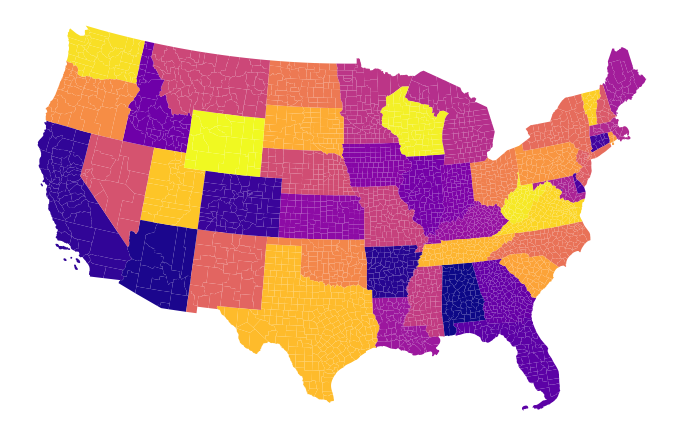

```python
fig, ax = plt.subplots(figsize=(12,10), subplot_kw=dict(aspect='equal'))
US48.plot(column='STATE', cmap='plasma',  ax=ax);
ax.set_axis_off()
plt.show()
```

## Get Census Data using API

**Request and API key [here](https://api.census.gov/data/key_signup.html)**

Use your key to get the following data for all counties: ACS 2018, 5 yr est.

*Universe:* Population 25 years and over in the United States (Educational Attainment)

- B06009_006E Total Graduate or Professional Degree Est
- B06009_006M Total Graduate or Professional Degree MOE

Example url = 'https://api.census.gov/data/2018/acs/acs5?get=B06009_006E,B06009_006M,NAME&for=county:*&key=YOURAPIKEY'

```python
# You can store the CENSUS_APPTOKEN in your user environment, like the SODAPY key, or
# enter your key as a text string here. eg. mykey='1234ABCD56789'

mykey = os.environ.get("CENSUS_APPTOKEN")
base = 'https://api.census.gov/data/2018/acs/acs5?get=NAME,GEO_ID,'
fields = 'B06009_006E,B06009_006M'
geog = '&for=county:*&key='

urld = base+fields+geog+mykey

%time r = requests.get(urld)
edu_data=r.json()
```

```
Wall time: 849 ms
```

```python
labels = edu_data[0][0:]
print(labels)
del edu_data[:1]
df=pd.DataFrame.from_dict(edu_data,orient = 'columns')
df.columns=labels
df=df.loc[df.state.astype('int').isin(stfips.STFIPS)].reset_index()
df.tail()
```

```
['NAME', 'GEO_ID', 'B06009_006E', 'B06009_006M', 'state', 'county']
```

|  | index | NAME | GEO_ID | B06009_006E | B06009_006M | state | county |
| --- | --- | --- | --- | --- | --- | --- | --- |
| 3103 | 3215 | Clayton County, Iowa | 0500000US19043 | 496 | 85 | 19 | 043 |
| 3104 | 3216 | Buena Vista County, Iowa | 0500000US19021 | 755 | 117 | 19 | 021 |
| 3105 | 3217 | Guthrie County, Iowa | 0500000US19077 | 393 | 80 | 19 | 077 |
| 3106 | 3218 | Humboldt County, Iowa | 0500000US19091 | 304 | 74 | 19 | 091 |
| 3107 | 3219 | Washington County, Iowa | 0500000US19183 | 945 | 149 | 19 | 183 |

## Join attribute table to spatial data (county boundaries)

> Notice that the GEOID in the county boundary files is a combination of the state and county FIPS. However, the GEO_ID in the attribute table has additional characters ('050000US). Before the tables are joined, create a new geoid field in the attribute table that combine the state and county fields.

```python
#show all columns
pd.set_option('display.max_columns', None)
#show all lines
pd.set_option('display.max_rows', None)
```

```python
df['geoid']= df['state'].astype('str')+ df['county']
jdf=US48.merge(df, left_on='GEOID', right_on='geoid')

jdf.tail()
```

|  | index_x | GEOID | STATE | COUNTY | BASENAME | geometry | index_y | NAME | GEO_ID | B06009_006E | B06009_006M | state | county | geoid |
| --- | --- | --- | --- | --- | --- | --- | --- | --- | --- | --- | --- | --- | --- | --- |
| 3103 | 3137 | 28143 | 28 | 143 | Tunica | POLYGON ((503613.003 -294129.666, 503610.663 -... | 2700 | Tunica County, Mississippi | 0500000US28143 | 324 | 127 | 28 | 143 | 28143 |
| 3104 | 3138 | 29081 | 29 | 081 | Harrison | POLYGON ((150084.491 334308.427, 150084.888 33... | 100 | Harrison County, Missouri | 0500000US29081 | 324 | 70 | 29 | 081 | 29081 |
| 3105 | 3139 | 18005 | 18 | 005 | Bartholomew | POLYGON ((846904.111 236946.898, 846905.332 23... | 2277 | Bartholomew County, Indiana | 0500000US18005 | 7224 | 555 | 18 | 005 | 18005 |
| 3106 | 3140 | 13223 | 13 | 223 | Paulding | POLYGON ((1009510.003 -336117.858, 1009508.815... | 2072 | Paulding County, Georgia | 0500000US13223 | 7947 | 739 | 13 | 223 | 13223 |
| 3107 | 3141 | 39015 | 39 | 015 | Brown | POLYGON ((1025246.219 220988.472, 1025249.759 ... | 2869 | Brown County, Ohio | 0500000US39015 | 1407 | 279 | 39 | 015 | 39015 |

## Calculate z-score

> Set the value of the number of persons 25+ with Graduate or Professional Degree Est (B06009_006E) to zero (0) if the z-score < 1.645.

```python
jdf['zscore']= jdf['B06009_006E'].astype(float)/(jdf['B06009_006M'].astype(float)/1.645)
jdf.loc[jdf['zscore'].abs() < 1.645,'B06009_006E']=0  #set estimate to 0
```

```python
jdf.tail()
```

|  | index_x | GEOID | STATE | COUNTY | BASENAME | geometry | index_y | NAME | GEO_ID | B06009_006E | B06009_006M | state | county | geoid | zscore |
| --- | --- | --- | --- | --- | --- | --- | --- | --- | --- | --- | --- | --- | --- | --- | --- |
| 3103 | 3137 | 28143 | 28 | 143 | Tunica | POLYGON ((503613.003 -294129.666, 503610.663 -... | 2700 | Tunica County, Mississippi | 0500000US28143 | 324 | 127 | 28 | 143 | 28143 | 4.196693 |
| 3104 | 3138 | 29081 | 29 | 081 | Harrison | POLYGON ((150084.491 334308.427, 150084.888 33... | 100 | Harrison County, Missouri | 0500000US29081 | 324 | 70 | 29 | 081 | 29081 | 7.614000 |
| 3105 | 3139 | 18005 | 18 | 005 | Bartholomew | POLYGON ((846904.111 236946.898, 846905.332 23... | 2277 | Bartholomew County, Indiana | 0500000US18005 | 7224 | 555 | 18 | 005 | 18005 | 21.411676 |
| 3106 | 3140 | 13223 | 13 | 223 | Paulding | POLYGON ((1009510.003 -336117.858, 1009508.815... | 2072 | Paulding County, Georgia | 0500000US13223 | 7947 | 739 | 13 | 223 | 13223 | 17.689871 |
| 3107 | 3141 | 39015 | 39 | 015 | Brown | POLYGON ((1025246.219 220988.472, 1025249.759 ... | 2869 | Brown County, Ohio | 0500000US39015 | 1407 | 279 | 39 | 015 | 39015 | 8.295753 |

# Complete the Spatial Autocorrelation Analysis Using this Geodataframe